# Heart Disease Prediction

A. Nguyen, B. Waite

7/17/2019

#Introduction:

This study hopes to identify factors contributing to the development of heart disease in an observed population and to train a logistic regression model to predict whether future patients will develop heart disease given the same set of factors.

#Data:

The data used in this study were obtained from the archives of the University of California, Irvine and are available on the web at: https://archive.ics.uci.edu/ml/datasets/Heart+Disease.

A brief summary of the variables contained in the data is available in the table below. A more robust description of each variable is contained in Appendix A.

| Variable | Description | Units or Value | Usage |
| --- | --- | --- | --- |
| age | Age | Years | Predictor |
| sex | Sex | 1 = Male;0 = Female | Predictor |
| cp | Chest Pain Type | 1 = Typical Angina, 2 = Atypical Angina, 3 = Non-Anginal Pain, 4 = Asymptomatic | Predictor |
| trestbps | Resting Blood Pressure at Admission | mmHg | Predictor |
| chol | Serum Cholesterol | mg/dl | Predictor |
| fbs | Fasting Blood Sugar > 120 mg/dl | 1 = true; 0 = false | Predictor |
| restecg | Resting Electrocardiographic Results | 0 = Normal, 1 = Having ST-T Wave Abnormality, 2 = Showing Probable or Definite left ventricular hypertrophy | Predictor |
| thalach | Maximum Heart Rate Achieved | Beats Per Minute (BPM) | Predictor |
| exang | Exercised Induced Angina | 1 = Yes; 0 = No | Predictor |
| oldpeak | ST Depression Induced by exercise relative to rest | Unknown | Predictor |
| slope | The Slope of the Peak Exercise ST Segment | 1 = Upsloping, 2 = Flat, 3 = Downsloping | Predictor |
| ca | Number of Major Vessels Colored by Flouroscopy | 0-3 | Predictor |
| thal | Severity of Defect | 3 = normal; 6 = fixed defect; 7 = reversable defect | Predictor |
| target | Diagnosis of Heart Disease | 0 = No Heart Disease Diagnosed; 1 = Heart Disease Diagnosed | Response |

Some interesting breakdowns:

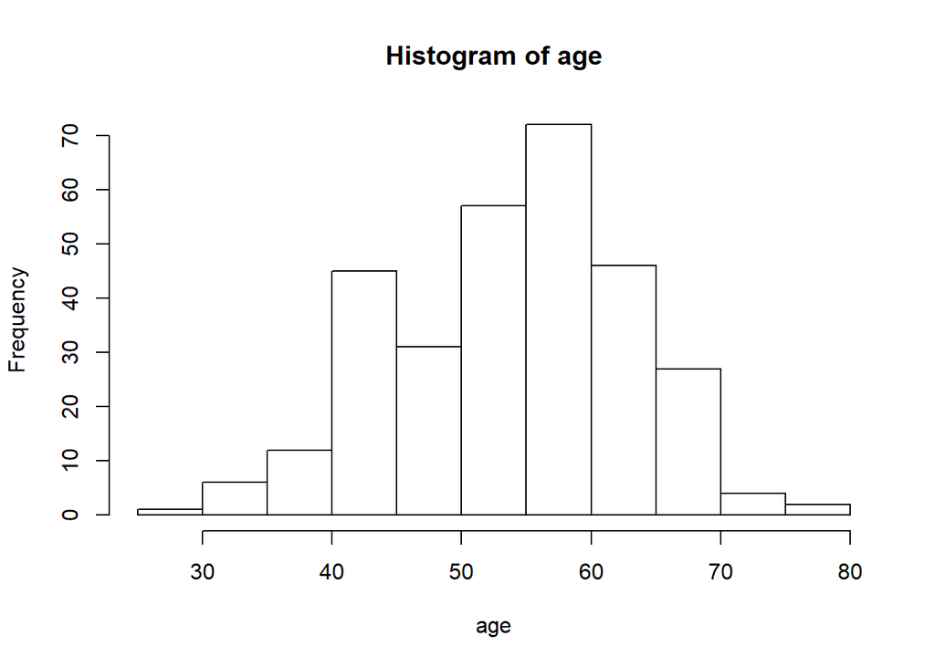

```r
#Age distribution
hist(age)
```

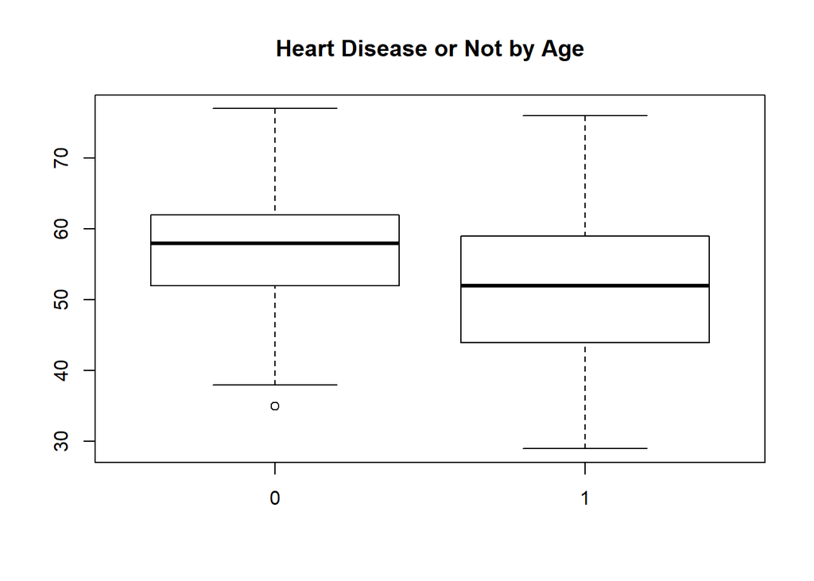

```r
#Heart Disease or not by Age
boxplot(age~target, main = "Heart Disease or Not by Age")
```

```r
#Sex breakdown
kable(table(sex))
```

| sex | Freq |
| --- | --- |
| 0 | 96 |
| 1 | 207 |

```r
#Chest pain breakdown
kable(table(cp))
```

| cp | Freq |
| --- | --- |
| 0 | 143 |
| 1 | 50 |
| 2 | 87 |
| 3 | 23 |

Interesting to note here that Chest Pain is listed in the data description as values 1-4, but here is 0-3. We can probably just adjust the description.

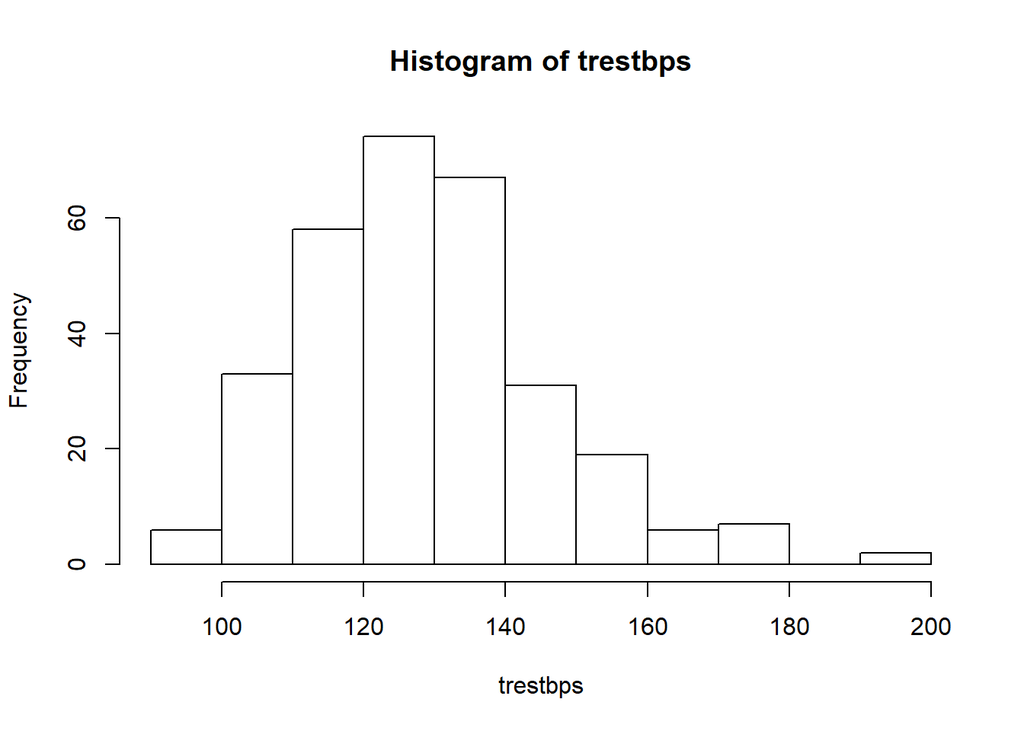

```r
#Histogram of trestbps
hist(trestbps)
```

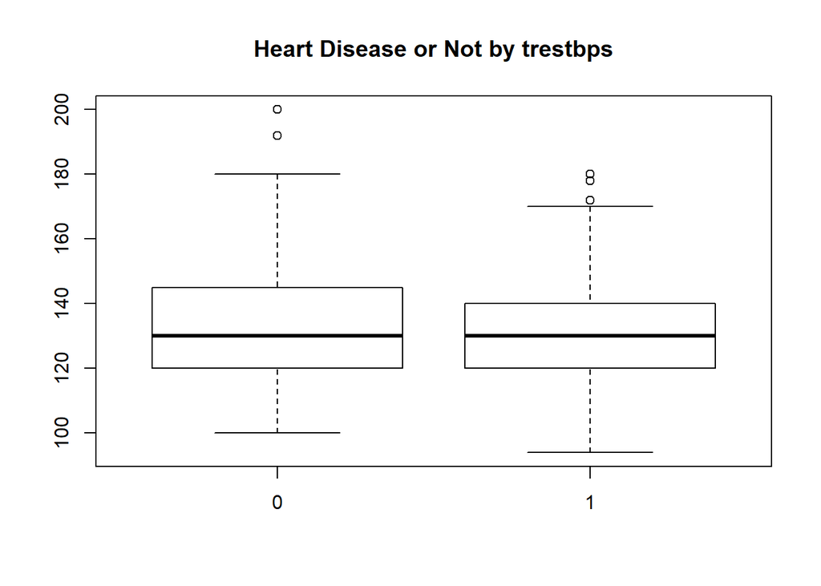

```r
#Boxplot of trestbps by response
boxplot(trestbps~target, main = "Heart Disease or Not by trestbps")
```

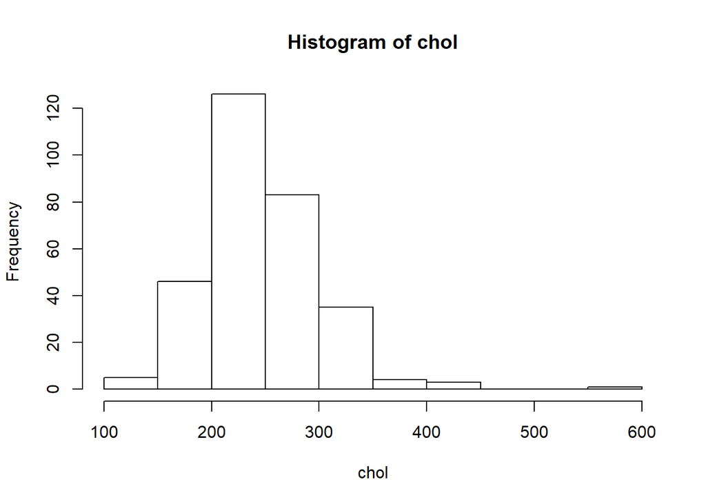

```r
#Histogram of chol
hist(chol)
```

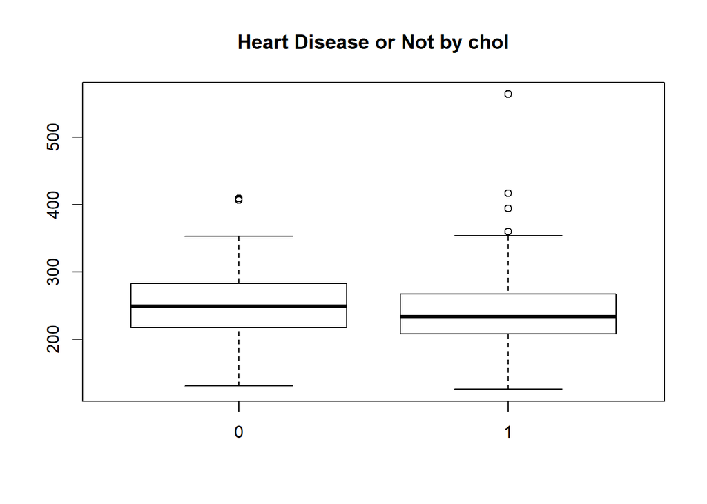

```r
#Boxplot of chol vs response
boxplot(chol~target, main = "Heart Disease or Not by chol")
```

```r
#Values of fbs in the data set
kable(table(fbs))
```

| fbs | Freq |
| --- | --- |
| 0 | 258 |
| 1 | 45 |

```r
#Values of restecg in the data set
kable(table(restecg))
```

| restecg | Freq |
| --- | --- |
| 0 | 147 |
| 1 | 152 |
| 2 | 4 |

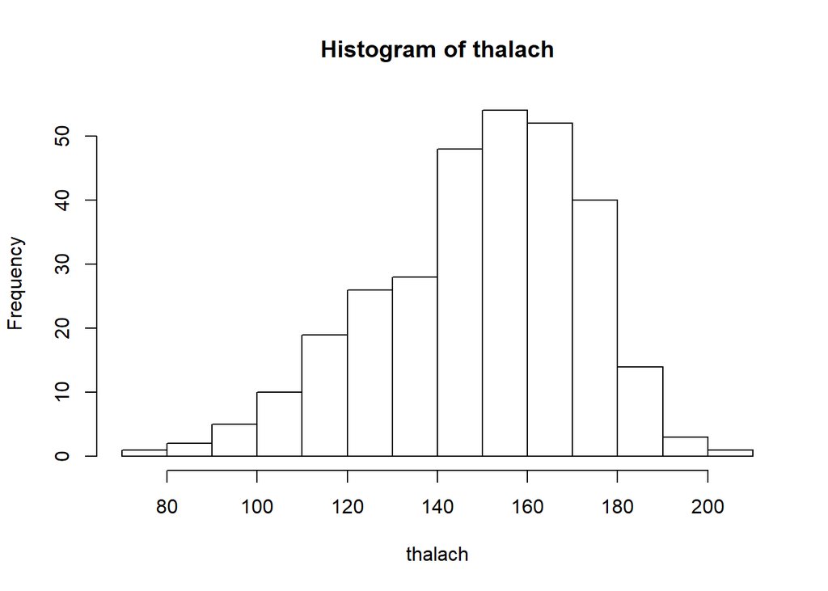

```r
#Histogram of thalach
hist(thalach)
```

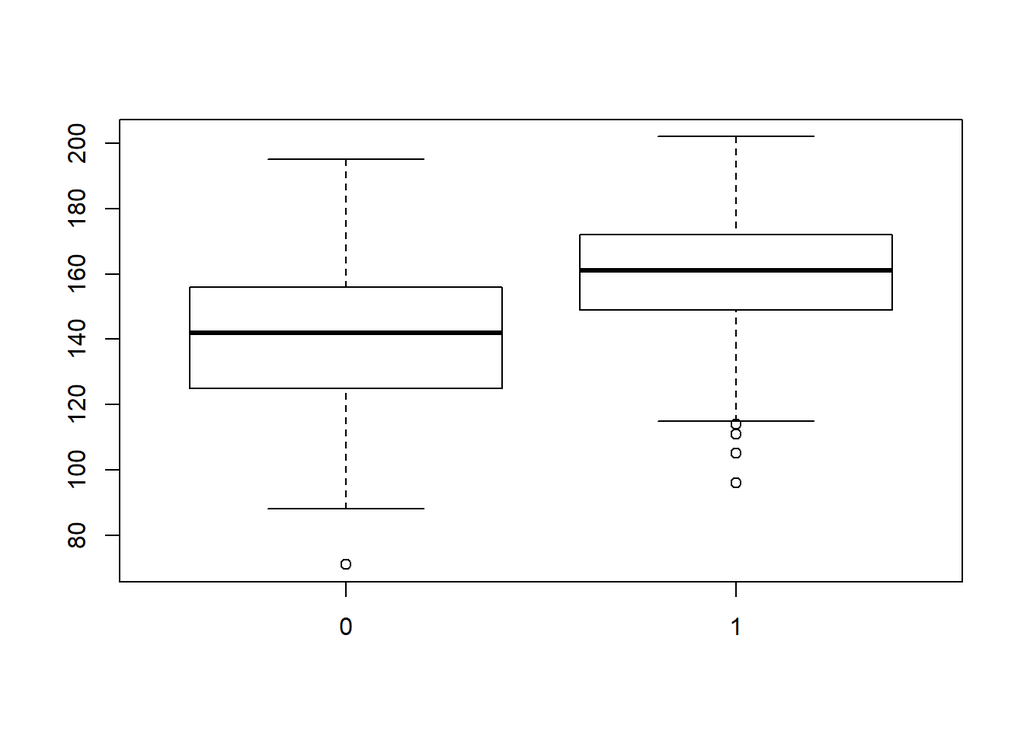

```r
#Boxplot of thalach against response
boxplot(thalach~target)
```

```r
#Some good differentiation here

#Values of exang in the data
kable(table(exang))
```

| exang | Freq |
| --- | --- |
| 0 | 204 |
| 1 | 99 |

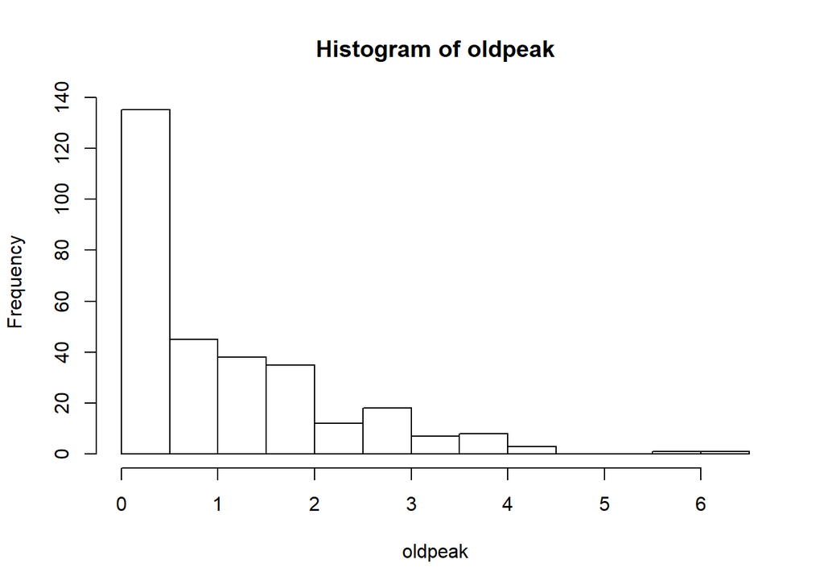

```r
#Histogram of oldpeak
hist(oldpeak)
```

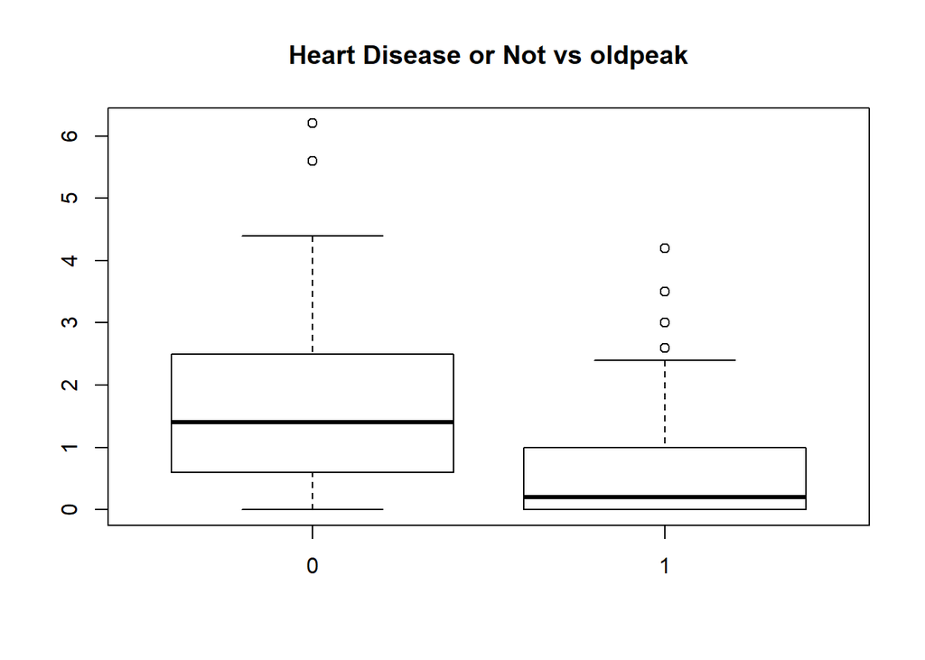

```r
#Some strong right skew here that may need to be addressed if we use this as a continuous variable. And I think we should initially.

#Boxplot of oldpeak
boxplot(oldpeak~target, main = "Heart Disease or Not vs oldpeak")
```

```r
#Values of slope occuring
kable(table(slope))
```

| slope | Freq |
| --- | --- |
| 0 | 21 |
| 1 | 140 |
| 2 | 142 |

```r
#Values of ca occuring
kable(table(ca))
```

| ca | Freq |
| --- | --- |
| 0 | 175 |
| 1 | 65 |
| 2 | 38 |
| 3 | 20 |
| 4 | 5 |

```r
#Values of thal occuring
kable(table(thal))
```

| thal | Freq |
| --- | --- |
| 0 | 2 |
| 1 | 18 |
| 2 | 166 |
| 3 | 117 |

```r
#Distribution of the target response seems roughly 50-50
kable(table(target))
```

| target | Freq |
| --- | --- |
| 0 | 138 |
| 1 | 165 |

Read in the data:

```r
library(readr)
library(knitr)
library(kableExtra)

#Requires setwd() to the current directory with heart.csv
heart <- read_csv("heart.csv")
```

Get summary statistics:

```r
summary(heart)
```

```
##       age             sex               cp           trestbps
##  Min.   :29.00   Min.   :0.0000   Min.   :0.000   Min.   : 94.0
##  1st Qu.:47.50   1st Qu.:0.0000   1st Qu.:0.000   1st Qu.:120.0
##  Median :55.00   Median :1.0000   Median :1.000   Median :130.0
##  Mean   :54.37   Mean   :0.6832   Mean   :0.967   Mean   :131.6
##  3rd Qu.:61.00   3rd Qu.:1.0000   3rd Qu.:2.000   3rd Qu.:140.0
##  Max.   :77.00   Max.   :1.0000   Max.   :3.000   Max.   :200.0
##       chol            fbs            restecg          thalach
##  Min.   :126.0   Min.   :0.0000   Min.   :0.0000   Min.   : 71.0
##  1st Qu.:211.0   1st Qu.:0.0000   1st Qu.:0.0000   1st Qu.:133.5
##  Median :240.0   Median :0.0000   Median :1.0000   Median :153.0
##  Mean   :246.3   Mean   :0.1485   Mean   :0.5281   Mean   :149.6
##  3rd Qu.:274.5   3rd Qu.:0.0000   3rd Qu.:1.0000   3rd Qu.:166.0
##  Max.   :564.0   Max.   :1.0000   Max.   :2.0000   Max.   :202.0
##      exang           oldpeak         slope             ca
##  Min.   :0.0000   Min.   :0.00   Min.   :0.000   Min.   :0.0000
##  1st Qu.:0.0000   1st Qu.:0.00   1st Qu.:1.000   1st Qu.:0.0000
##  Median :0.0000   Median :0.80   Median :1.000   Median :0.0000
##  Mean   :0.3267   Mean   :1.04   Mean   :1.399   Mean   :0.7294
##  3rd Qu.:1.0000   3rd Qu.:1.60   3rd Qu.:2.000   3rd Qu.:1.0000
##  Max.   :1.0000   Max.   :6.20   Max.   :2.000   Max.   :4.0000
##       thal           target
##  Min.   :0.000   Min.   :0.0000
##  1st Qu.:2.000   1st Qu.:0.0000
##  Median :2.000   Median :1.0000
##  Mean   :2.314   Mean   :0.5446
##  3rd Qu.:3.000   3rd Qu.:1.0000
##  Max.   :3.000   Max.   :1.0000
```

```r
attach(heart)
```

Variable names and meanings pulled from the source website: https://archive.ics.uci.edu/ml/datasets/Heart+Disease

```r
vartable = as.data.frame(names(heart))
vartable$description = c("Age","Sex","Chest Pain Type","Resting Blood Pressure at Admission","Serum Cholesterol","Fasting Blood Sugar > 120 mg/dl","Resting Electrocardiographic Results","Maximum Heart Rate Achieved","Exercised Induced Angina",
                         "Stress Test Depression Induced by exercise relative to rest", "The Slope of the Peak Exercise Stress Test Segment","Number of Major Vessels Colored by Flouroscopy", "Severity of Defect","Diagnosis of Heart Disease")
vartable$typeOrUnits = c("Years", "1 = Male;0 = Female", "1 = Typical Angina, 2 = Atypical Angina, 3 = Non-Anginal Pain, 4 = Asymptomatic", "mmHg","mg/dl","1 = true; 0 = false","0 = Normal, 1 = Having Stress Test T-Wave Abnormality, 2 = Showing Probable or Definite left ventricular hypertrophy","Beats Per Minute (BPM)","1 = Yes; 0 = No","Unknown","1 = Upsloping, 2 = Flat, 3 = Downsloping","0-3","3 = normal; 6 = fixed defect; 7 = reversable defect","0 = No Heart Disease Diagnosed; 1 = Heart Disease Diagnosed")
vartable$usage = "Predictor"
vartable$usage[14] = "Response"
names(vartable) = c("Variable","Description","Units or Value","Usage")
kable(vartable) %>%
  kable_styling(bootstrap_options = c("striped", "hover"))
```

| Variable | Description | Units or Value | Usage |
| --- | --- | --- | --- |
| age | Age | Years | Predictor |
| sex | Sex | 1 = Male;0 = Female | Predictor |
| cp | Chest Pain Type | 1 = Typical Angina, 2 = Atypical Angina, 3 = Non-Anginal Pain, 4 = Asymptomatic | Predictor |
| trestbps | Resting Blood Pressure at Admission | mmHg | Predictor |
| chol | Serum Cholesterol | mg/dl | Predictor |
| fbs | Fasting Blood Sugar > 120 mg/dl | 1 = true; 0 = false | Predictor |
| restecg | Resting Electrocardiographic Results | 0 = Normal, 1 = Having Stress Test T-Wave Abnormality, 2 = Showing Probable or Definite left ventricular hypertrophy | Predictor |
| thalach | Maximum Heart Rate Achieved | Beats Per Minute (BPM) | Predictor |
| exang | Exercised Induced Angina | 1 = Yes; 0 = No | Predictor |
| oldpeak | Stress Test Depression Induced by exercise relative to rest | Unknown | Predictor |
| slope | The Slope of the Peak Exercise Stress Test Segment | 1 = Upsloping, 2 = Flat, 3 = Downsloping | Predictor |
| ca | Number of Major Vessels Colored by Flouroscopy | 0-3 | Predictor |
| thal | Severity of Defect | 3 = normal; 6 = fixed defect; 7 = reversable defect | Predictor |
| target | Diagnosis of Heart Disease | 0 = No Heart Disease Diagnosed; 1 = Heart Disease Diagnosed | Response |

Some interesting breakdowns:

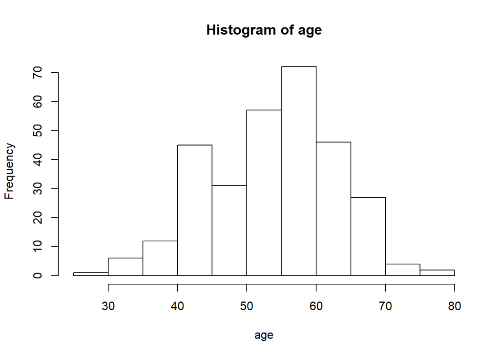

```r
#Age distribution
hist(age)
```

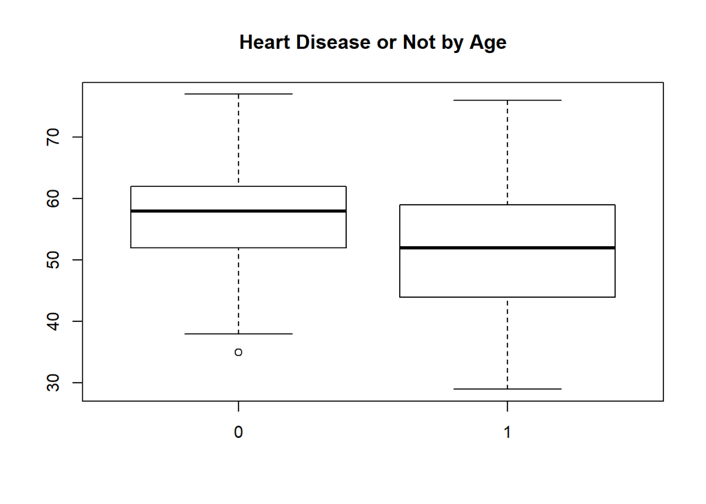

```r
#Heart Disease or not by Age
boxplot(age~target, main = "Heart Disease or Not by Age")
```

```r
#Sex breakdown
kable(table(sex))
```

| sex | Freq |
| --- | --- |
| 0 | 96 |
| 1 | 207 |

```r
#Chest pain breakdown
kable(table(cp))
```

| cp | Freq |
| --- | --- |
| 0 | 143 |
| 1 | 50 |
| 2 | 87 |
| 3 | 23 |

Interesting to note here that Chest Pain is listed in the data description as values 1-4, but here is 0-3. We can probably just adjust the description.

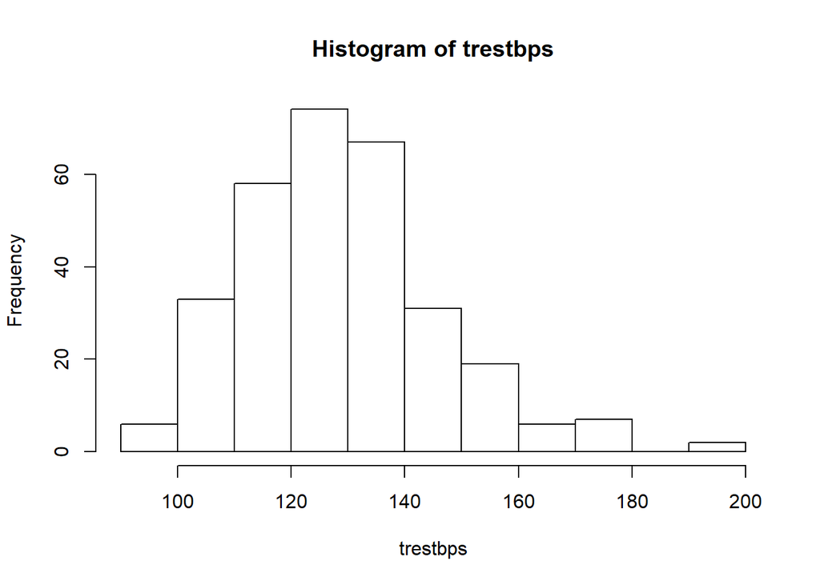

```r
#Histogram of trestbps
hist(trestbps)
```

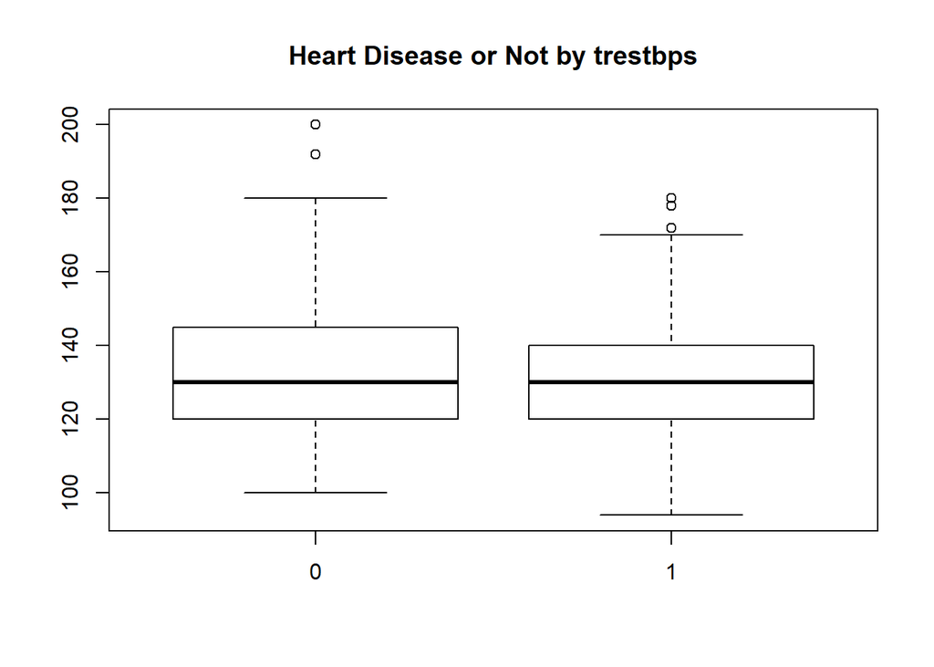

```r
#Boxplot of trestbps by response
boxplot(trestbps~target, main = "Heart Disease or Not by trestbps")
```

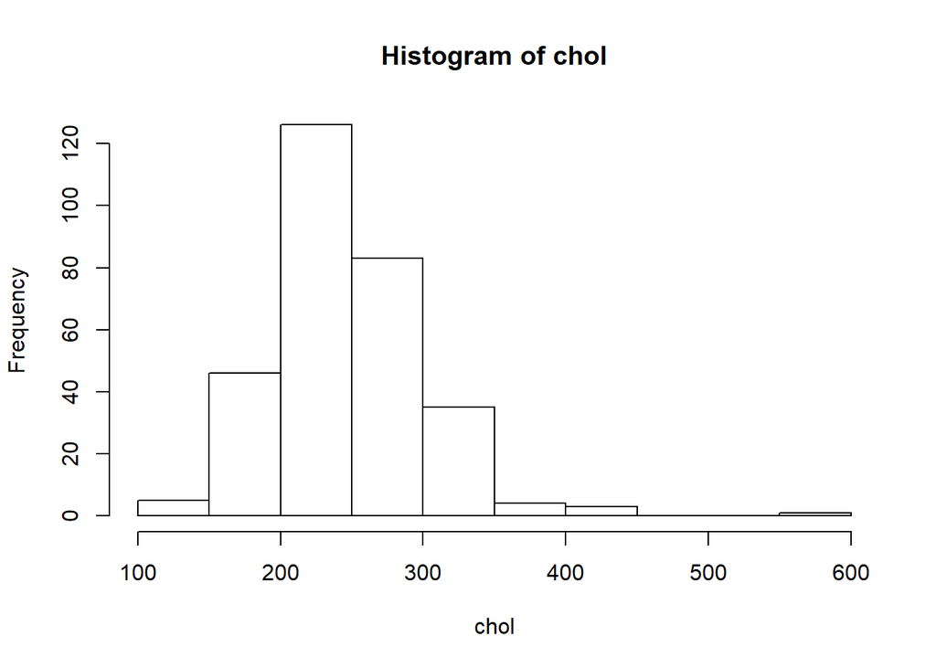

```r
#Histogram of chol
hist(chol)
```

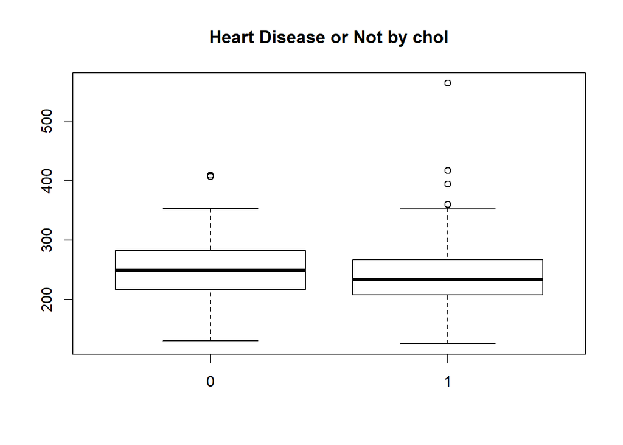

```r
#Boxplot of chol vs response
boxplot(chol~target, main = "Heart Disease or Not by chol")
```

```r
#Values of fbs in the data set
kable(table(fbs))
```

| fbs | Freq |
| --- | --- |
| 0 | 258 |
| 1 | 45 |

```r
#Values of restecg in the data set
kable(table(restecg))
```

| restecg | Freq |
| --- | --- |
| 0 | 147 |
| 1 | 152 |
| 2 | 4 |

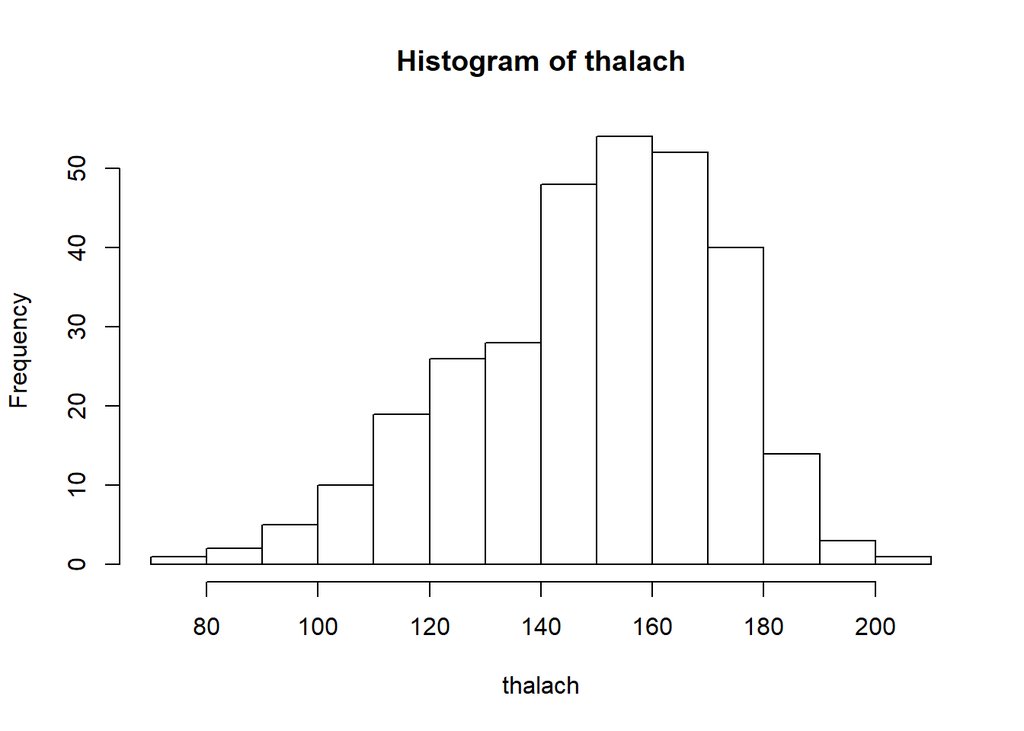

```r
#Histogram of thalach
hist(thalach)
```

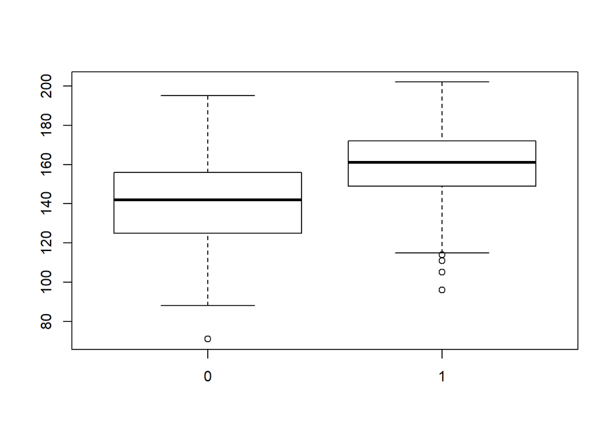

```r
#Boxplot of thalach against response
boxplot(thalach~target)
```

```r
#Some good differentiation here

#Values of exang in the data
kable(table(exang))
```

| exang | Freq |
| --- | --- |
| 0 | 204 |
| 1 | 99 |

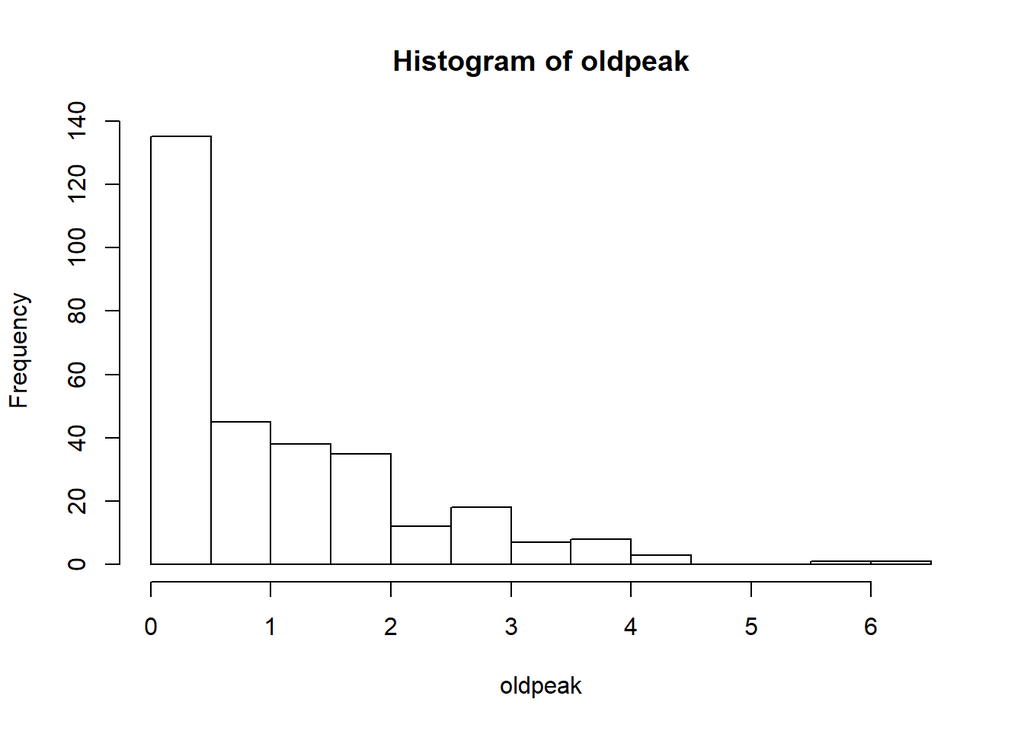

```r
#Histogram of oldpeak
hist(oldpeak)
```

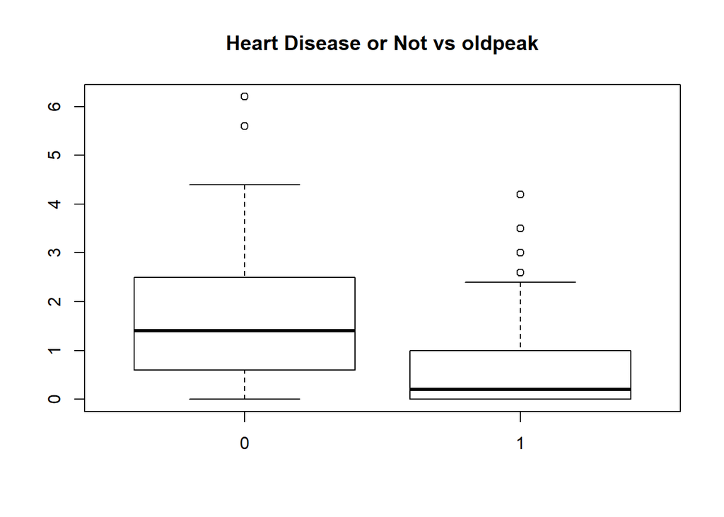

```r
#Some strong right skew here that may need to be addressed if we use this as a continuous variable. And I think we should initially.

#Boxplot of oldpeak
boxplot(oldpeak~target, main = "Heart Disease or Not vs oldpeak")
```

```r
#Values of slope occuring
kable(table(slope))
```

| slope | Freq |
| --- | --- |
| 0 | 21 |
| 1 | 140 |
| 2 | 142 |

```r
#Values of ca occuring
kable(table(ca))
```

| ca | Freq |
| --- | --- |
| 0 | 175 |
| 1 | 65 |
| 2 | 38 |
| 3 | 20 |
| 4 | 5 |

```r
#Values of thal occuring
kable(table(thal))
```

| thal | Freq |
| --- | --- |
| 0 | 2 |
| 1 | 18 |
| 2 | 166 |
| 3 | 117 |

```r
#Distribution of the target response seems roughly 50-50
kable(table(target))
```

| target | Freq |
| --- | --- |
| 0 | 138 |
| 1 | 165 |

##Let’s try to do some PCA:

Get the continuous variables

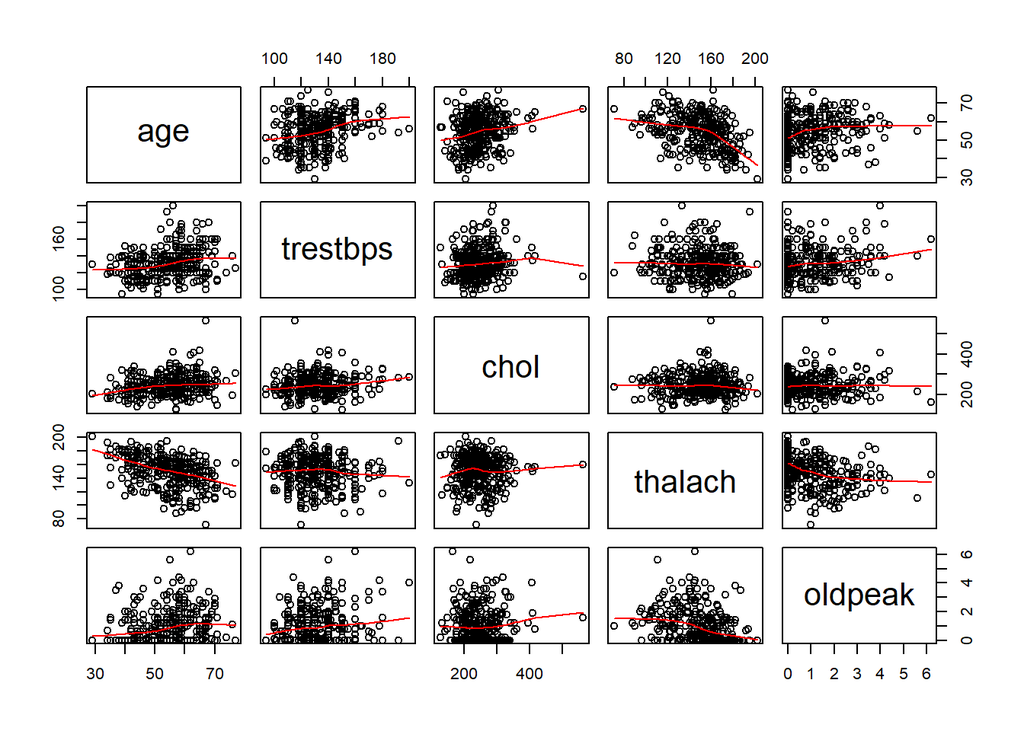

```r
heartcont = heart[,c('age','trestbps','chol','thalach','oldpeak')]
pairs(heartcont, panel = panel.smooth)
```

Looking at these plots, there does not seem to be much correlation between the continuous variables. The heatmap below seems to confirm this.

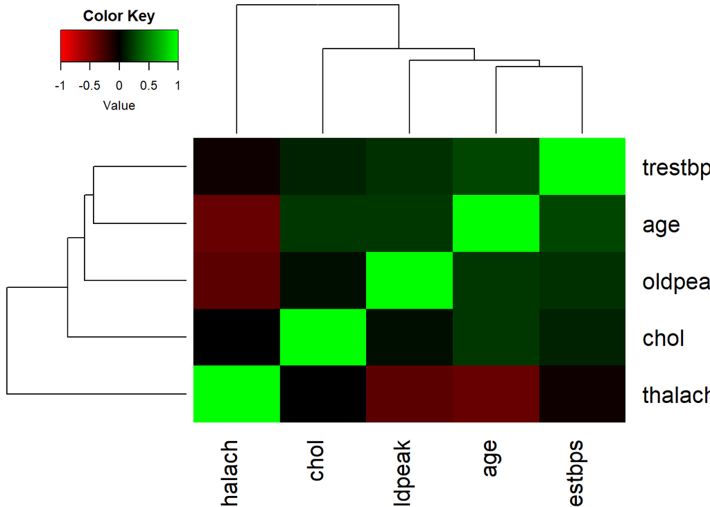

```r
library(gplots)
my.cor2 = cor(heartcont)
heatmap.2(my.cor2,col=redgreen(75),
          density.info="none", trace="none", dendrogram=c("both"),
          symm=F,symkey=T,symbreaks=T, scale="none",key=T)
```

```r
cov(heartcont)
```

```
##                 age   trestbps        chol    thalach   oldpeak
## age       82.484558  44.495902  100.585076 -82.903318  2.214583
## trestbps  44.495902 307.586453  111.967215 -18.759131  3.934486
## chol     100.585076 111.967215 2686.426748 -11.800494  3.246794
## thalach  -82.903318 -18.759131  -11.800494 524.646406 -9.153518
## oldpeak    2.214583   3.934486    3.246794  -9.153518  1.348095
```

Looking at Principal Components with scaling (using the correlation values vice the covariance values).

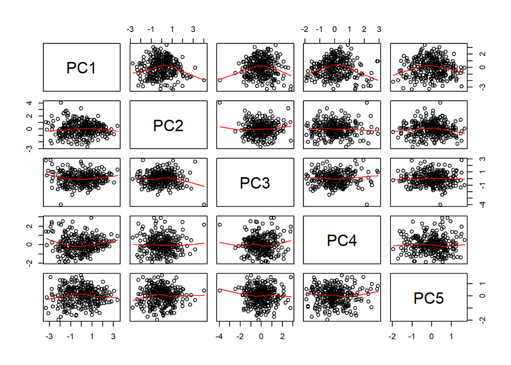

```r
pcomps = prcomp(heartcont,scale. = TRUE)
pcscores = pcomps$x
pairs(pcscores, panel = panel.smooth)
```

There do not seem to be any correlations in the Principal Components. Let’s try to produce the Scree / Cumulative Proportion Plots:

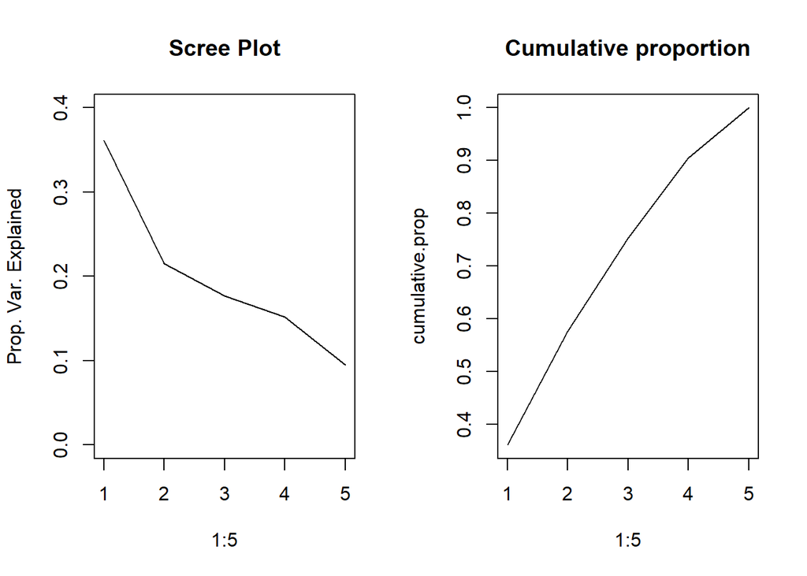

```r
par(mfrow=c(1,2))
eigenvals<-(pcomps$sdev)^2
plot(1:5,eigenvals/sum(eigenvals),type="l",main="Scree Plot",ylab="Prop. Var. Explained", ylim = c(0,.4))
cumulative.prop<-cumsum(eigenvals/sum(eigenvals))
plot(1:5,cumulative.prop,type="l",main="Cumulative proportion")# ,ylim=c(0,1))
```

```r
par(mfrow=c(1,1))
```

It looks like from the above plot, that approximately 90% of the variability can be explained using 4 principal components. It does appear, though that all 5 continue to contribute to the model which is consistent with our earlier assessment that there is not significant correlation among the predictors.

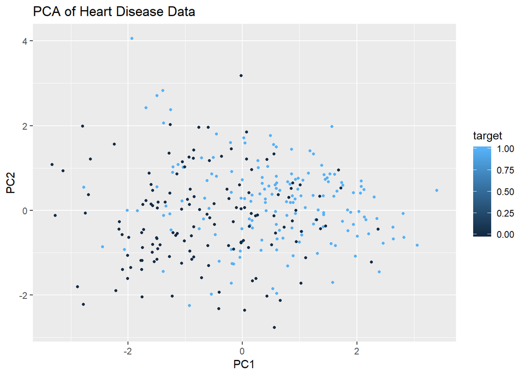

```r
pcscores = data.frame(pcscores)
ggplot(data = pcscores, aes(x = PC1, y = PC2)) +
  geom_point(aes(col=target), size=1)+
  ggtitle("PCA of Heart Disease Data")
```

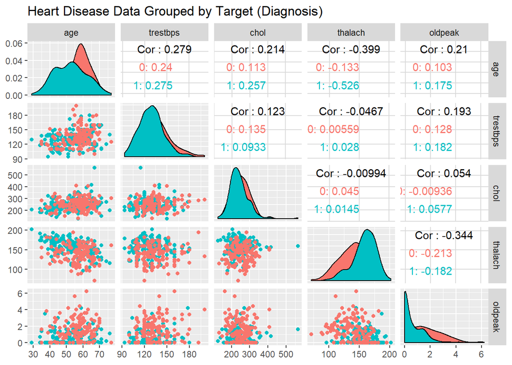

```r
heartcont$target = as.factor(heart$target)

#pairs on variables grouped by target
library(GGally)
ggpairs(heartcont, columns=1:5, aes(color=target)) +
  ggtitle("Heart Disease Data Grouped by Target (Diagnosis)")
```

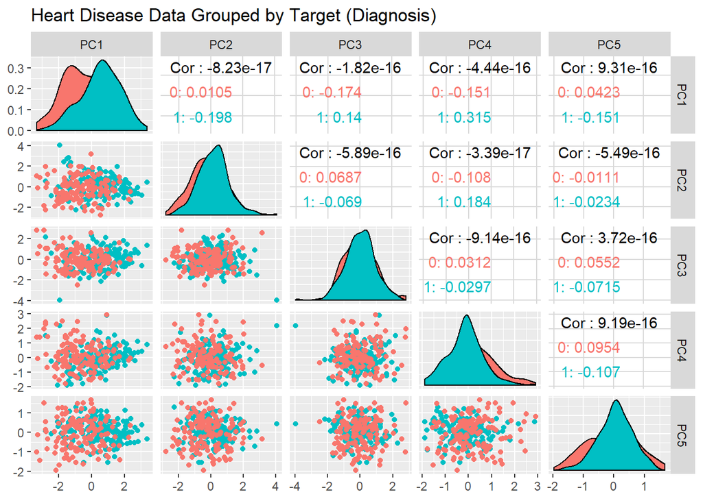

```r
#pairs on principal components grouped by target
pcscores$target = as.factor(heart$target)
ggpairs(pcscores, columns=1:5, aes(color=target)) +
  ggtitle("Heart Disease Data Grouped by Target (Diagnosis)")
```

Running a number of PCA charts coded by response does not appear to show a clean discriminant that we can use to do regression on the Principal Components. Principal component 1 (PC1) does show some ability to distinguish against PC2, but there is still significant overlap. This could mean that our logistic model will not perform super well. It could also mean that we just don’t have very many continuous predictors and that the categorical predictors will really help us differentiate with interaction terms.

Looking at the weighting on the principal components:

```r
pcomps$rotation
```

```
##                 PC1        PC2        PC3        PC4        PC5
## age      -0.5673990  0.1084469 -0.1783796 -0.5199937  0.6033944
## trestbps -0.3758463  0.4231668  0.7394680 -0.1439024 -0.3348860
## chol     -0.2453800  0.6922836 -0.5317555  0.3781374 -0.1864944
## thalach   0.5056805  0.4824636  0.2983680  0.1733984  0.6264389
## oldpeak  -0.4699721 -0.3116750  0.2226667  0.7320135  0.3107422
```

In looking at this table, we can see that each variable contributes a significant amount in at least one of the Principal Components. This is a good indication that the variables are not correlated with each other and that each might contribute something unique to our model.

# Appendix A:

Variable names and meanings pulled from the source website: https://archive.ics.uci.edu/ml/datasets/Heart+Disease

*Chest Pain Type (cp)* [SOURCE: https://www.aafp.org/afp/2005/1115/p2012.html]

Angina is chest pain that results from reduced blood flow to the heart muscle.

Typical angina (definite chest pain) meets three of the following characteristics

1. Substernal chest discomfort of characteristic quality and duration
2. Provoked by exertion or emotional stress
3. Relieved by rest and/or nitroglycerine

Atypical angina (probable chest pain) meets two of the characteristics

Non-anginal pain meets one characteristic

Asymptomatic means no chest pain

*Resting Blood Pressure (trestbps)*

High blood pressure is a common condition and major risk factor for heart disease. Uncontrolled hypertension can lead to heart attack and stroke

*Serum Cholesterol (chol)*

[SOURCE: https://www.medicalnewstoday.com/articles/321519.php]

Serum cholesterol measures the amount of triglycerides, low-density lipoprotein (LDL/bad cholesterol), and high density lipoprotein (HDL/good cholesterol). High serum cholesterol levels are associated with higher risk for coronary artery disease and heart attack

*Normal Ranges for cholesterol levels*

<= 19 years old - serum chol [<= 170 mg/dL] - HDL [>= 45 mg/dL] - LDL [< 100 mg/dL] - Triglycerides [< 150 mg/dL] >= 20 years old female - serum chol [125-200 mg/dL] - HDL [>= 50 mg/dL] - LDL [< 100 mg/dL] - Triglycerides [< 150 mg/dL] >= 20 years old male - serum chol [125-200 mg/dL] - HDL [>= 40 mg/dL] - LDL [< 100 mg/dL] - Triglycerides [< 150 mg/dL]

*Fasing Blood Sugar (fbs)*

[SOURCE: https://www.mayoclinic.org/diseases-conditions/diabetes/diagnosis-treatment/drc-20371451]

Ranges:

1. fbs < 100 mg/dL is normal
2. fbs 100-125 mg/dL is prediabetes
3. fbs >= 126 mg/dL on two separate tests diagnoses diabetes

A fasting blood sugar level of more than 125 mg/dL is current threshold for diabetes. Higher fasting blood sugars are associatied with higher risk for heart disease.

*Resting Electrocardiographic Results (restecg)*

[SOURCE: https://www.mayoclinic.org/diseases-conditions/left-ventricular-hypertrophy/symptoms-causes/syc-20374314]

ST-T Wave Abnormality (1) are associated with increased cardiac deaths and are highly suggestive of coronary artery disease when associcated with cardiac signs and symptoms. T wave inversions and/or ST elevation or depression of > 0.05 mV.

Left Ventricular Hypertrophy (2) is enlargement/thickening (hypertrophy) of the walls of your heart’s main pumping chamber (left ventricle) and causes it to work harder.

- Defined using Estes’ criteria
  - As the workload increases, the muscle tissue in the chamber wall thickens. The enlarged heart muscle loses elasticity and may eventually fail to pump with as much force as needed.
  - Left ventricular hypertrophy is more common in people who have uncontrolled high blood pressure and puts you at higher risk of a heart attack and stroke.

*Maximum Heart Rate Achieved (thalach)*

[SOURCE: https://www.hopkinsmedicine.org/health/wellness-and-prevention/understanding-your-target-heart-rate]

The maximum heart rate is based on your age, as subtracted from 220.

- For a 50-year-old, maximum heart rate is 220 minus 50, or 170 beats per minute.
  - Target heart rate that a 50-year-old would want to aim for during exercise is 85 to 145 beats per minute (50%-85% exertion level).
  - Maximum heart rates below these averages may indicate weakening of heart muscle

*Exercise Induced Angina*

Chest pain that is triggered by physical exertion. When you climb stairs, exercise or walk, your heart demands more blood, but it’s harder for the muscle to get enough blood when your arteries are narrowed.

*ST Depression Induced (oldpeak)*

[SOURCE: https://www.ahajournals.org/doi/pdf/10.1161/01.CIR.80.1.87]

- Units are in mm or mV?

ST segment depression in PQRST wave (ECG) may be assoicated with coronary artery disease with larger depressions indicative of abnormality. Exercise stress test requires an ST depression of at least 2 mm to significantly indicate reversible ischaemia [WIKI]

*Slope of Peak Exercise ST Segment (slope)*

[SOURCE: https://ecgwaves.com/ecg-topic/exercise-stress-test-ecg-symptoms-blood-pressure-heart-rate-performance/]

- Steep slopes indicate a less likely chance of ischemia
- Horizontal/Flat slopes indicate a more likely chance of ischemia

*Number of Major Vessels Colored by Flouroscopy (ca)*

*Severity of Defect (thal)*

*target*

Diagnosis of heart disease (angiographic disease status)

Value 0: < 50% diameter narrowing Value 1: > 50% diameter narrowing (in any major vessel: attributes 59 through 68 are vessels)